# PRÁCTICA 2: Detección de temas en política

Author

GAYEONG LEE & XAVIER VARELA & ÁNGELA RODRÍGUEZ

## 1. OBJETIVO DE LA PRÁCTICA

Nuestro objetivo es analizar las notas de prensa del Partido Popular (PP). A través del web scraping de estas notas, podremos explorar la frecuencia y distribución de palabras y temas clave, identificar patrones y tendencias en la comunicación del partido según el contexto político y social, y emplear técnicas de análisis de sentimientos para comprender mejor la actitud y el tono del partido hacia diferentes temas.

## 2. ESCRAPEAMOS LOS DOCUMENTOS

### NOTAS DE PRENSA DEL PP

Para obtener los documentos necesarios, hemos considerado oportuno utilizar la función **`for`**, la cual nos permite realizar un bucle para obtener las URL de las notas de prensa del Partido Popular (PP). Esta estrategia agiliza significativamente el proceso, ya que nos permite extraer hasta 200 URL del sitio web en cuestión de minutos.

```r
# Definir una lista vacía para almacenar los enlaces
all_links <- list()

num_pages <- 20
```

```r
for (i in 1:num_pages) {

  # Definir la URL de la página actual
  url <- paste0("https://www.pp.es/actualidad/noticias", "?page=", i)

  # Obtener el código HTML de la página actual
 html <- read_html(url)

  # Extraer los enlaces de los artículos de opinión de la página actual
  links <- html %>%
    html_nodes("a.titulo_sec") %>%
    html_attr("href")

  # Agregar los enlaces a la lista
  all_links <- append(all_links, list(links))

  # Agregar una pausa de 1 segundo entre cada solicitud para evitar sobrecargar el servidor
  Sys.sleep(1)
}

# Combinar todos los enlaces en una sola lista
all_links <- unlist(all_links)

all_links <- paste0("https://www.pp.es", all_links)

# Escribir los enlaces en un archivo de texto
writeLines(all_links, "PP.txt")
```

```r
head(all_links)
```

```
[1] "https://www.pp.es/actualidad-noticia/beatriz-fanjul-ministra-igualdad-tiene-tarea-deshacer-miles-despropositos-sus"
[2] "https://www.pp.es/actualidad-noticia/ester-munoz-afirma-que-unico-proyecto-pedro-sanchez-es-convertir-espana-un"
[3] "https://www.pp.es/actualidad-noticia/paloma-martin-advierte-que-nuestra-democracia-sera-irreconocible-si-se-permite"
[4] "https://www.pp.es/actualidad-noticia/pp-exige-que-gobierno-paralice-subida-al-21-iva-al-gas-electricidad-por-ser-una"
[5] "https://www.pp.es/actualidad-noticia/pp-rechaza-techo-gasto-tras-negativa-gobierno-bajar-iva-alimentos-basicos-energia"
[6] "https://www.pp.es/actualidad-noticia/requena-reclama-al-gobierno-que-abandone-unilateralidad-salida-espana-tratado"
```

```r
length(all_links)
```

```
[1] 200
```

### Formamos el data frame con el que se harán los análisis posteriores.

```r
url_editoriales <- read.table("pp.txt",stringsAsFactors = F)$V1
```

Utilizamos la biblioteca **`rvest`** para extraer los nodos HTML que contienen el texto del editorial y luego usamos la función **`html_text()`** para obtener el texto sin las etiquetas HTML. Finalmente, con **`str_replace_all()`** eliminamos los caracteres de retorno y nueva línea del texto.

```r
get_editorial_text <- function(url){
  url %>%
    read_html() %>%
    html_nodes("span.texto_noticia") %>%
    html_text() %>%
    str_replace_all("[\r\n]" , "")
}

text_editoriales <- sapply(url_editoriales,get_editorial_text)

data_text_editoriales <- data.frame(
  date=as.Date(str_extract(url_editoriales, "[0-9]{4}-[0-9]{2}-[0-9]{2}")),
  text = text_editoriales
)
#save(data_text_editoriales,file="text_editoriales2023.RData")

load(file = "text_editoriales2023.RData")
```

Utilizamos la función **`sapply()`** para aplicar la función **`get_editorial_text()`** a cada una de las URL de editoriales almacenadas en **`url_editoriales`** y almacenar el resultado en **`text_editoriales`**.

Más tarde ,una vez obtenidas estas url, utilizamos **`str_extract()`** para extraer la fecha de cada URL y convertir la cadena de fecha en formato año-mes-dia en un objeto de fecha con **`as.Date()`**

```r
head(data_text_editoriales)
```

```
                                                                                                                       date
https://www.pp.es/actualidad-noticia/feijoo-participara-medio-centenar-actos-este-mes-todas-las-ccaa-ceuta-melilla     <NA>
https://www.pp.es/actualidad-noticia/feijoo-reivindica-conocimiento-experiencia-politica-frente-al-adanismo            <NA>
https://www.pp.es/actualidad-noticia/feijoo-elogia-gestion-comunidad-madrid-ve-un-ejemplo-buenas-practicas-su-gobierno <NA>
https://www.pp.es/actualidad-noticia/gamarra-situa-al-pp-como-partido-trabajadores-autonomos-advierte-que-mejor        <NA>
https://www.pp.es/actualidad-noticia/bendodo-exige-sanchez-marlaska-una-explicacion-urgente-por-prohibir-participacion <NA>
https://www.pp.es/actualidad-noticia/gamarra-cinco-anos-sanchismo-no-se-borran-cinco-semanas-mas-promesas-mentiras     <NA>
                                                                                                                                                                                                                                                                                                            …
https://www.pp.es/actualidad-noticia/feijoo-participara-medio-centenar-actos-este-mes-todas-las-ccaa-ceuta-melilla                                                                                                                                                                                          …
https://www.pp.es/actualidad-noticia/feijoo-reivindica-conocimiento-experiencia-politica-frente-al-adanismo                                                                                                                                                                                                 …
https://www.pp.es/actualidad-noticia/feijoo-elogia-gestion-comunidad-madrid-ve-un-ejemplo-buenas-practicas-su-gobierno                                                                                                                                                                                      …
https://www.pp.es/actualidad-noticia/gamarra-situa-al-pp-como-partido-trabajadores-autonomos-advierte-que-mejor         • La secretaria general del Partido Popular recuerda que el Ejecutivo que hoy se manifiesta con motivo del Primero de mayo es el responsable de la pérdida de poder adquisitivo de l…
https://www.pp.es/actualidad-noticia/bendodo-exige-sanchez-marlaska-una-explicacion-urgente-por-prohibir-participacion                                                                                                                                                                                      …
https://www.pp.es/actualidad-noticia/gamarra-cinco-anos-sanchismo-no-se-borran-cinco-semanas-mas-promesas-mentiras                                                                                                                                                                                          …
```

## 3. Objetivos

### 3-1. Construimos la matriz de documentos.

#### Calculamos el sentimiento utilizando el método de diccionarios.

```r
afinn <- read.csv("lexico_afinn.en.es.csv", stringsAsFactors = F, fileEncoding = "latin1")

head(afinn)
```

```
     Palabra Puntuacion       Word
1    a bordo          1     aboard
2   abandona         -2   abandons
3 abandonado         -2  abandoned
4  abandonar         -2    abandon
5    abatido         -2   dejected
6    abatido         -3 despondent
```

Filtramos las palabras del diccionario según si su puntuación es positiva o negativa, y lo almacenamos en los objetos pos.words y neg.words, respectivamente.

```r
pos.words <- afinn$Palabra[afinn$Puntuacion>0]
neg.words <- afinn$Palabra[afinn$Puntuacion<0]
```

```r
sample(pos.words, 10)
```

```
 [1] "diversión"  "calma"      "animado"    "mejorando"  "retozón"
 [6] "saboreando" "iluminar"   "saliente"   "atrayendo"  "afecto"
```

```r
sample(neg.words, 10)
```

```
 [1] "gilipollas"   "singleminded" "no está bien" "mentiroso"    "retirada"
 [6] "mordaza"      "límites"      "ceñudo"       "suicida"      "convencido"
```

Luego, creamos un nuevo diccionario llamado mydict utilizando la función dictionary(), que toma como entrada una lista de palabras negativas y positivas que previamente habiamos filtrado.

```r
mydict <- dictionary(list(negative = neg.words,
                          positive = pos.words))
```

Para hacer más fácil el análisis de estos textos nos efocamos en la limpieza de los que se van a analizar. Primero, utilizamos la función **iconv()** para convertir los caracteres especiales (como los emojis) de los textos en caracteres legibles por R. Luego se eliminan con la funcion **regular gsub())** los espacios innecesarios.

```r
texts <- data_text_editoriales$text
texts <- iconv(texts,"UTF-8","latin1",sub=" ") #get rid of emojis, end-of-line characters
texts <- gsub("(RT|via)((?:\\b\\W*@\\w+)+)", " ", texts) #get rid of redata_text_editoriales
texts = gsub("@\\w+", " ", texts) #get rid of mentions
texts = gsub("[ \t]{2,}", " ", texts) #get rid of unnecessary spaces
texts = gsub("^\\s+|\\s+$", "", texts)
texts = gsub("\n"," ",texts) #remove line breaks
```

El siguiente paso que seguimos es tokenizar y quitar signos de puntuación. Con este paso, convertimos cada palabra del texto en un token, lo que nos permitirá posteriorimente hacer el análisis de sentimiento.

```r
data_tokens <- corpus(texts) %>%
  tokens(remove_punct = T,remove_numbers = T,
         remove_symbols = T, remove_url = T) %>%
  tokens_remove(tm::stopwords("spanish"))
```

```r
head(data_tokens)
```

```
Tokens consisting of 6 documents.
text1 :
 [1] "punto"      "álgido"     "campaña"    "lugar"      "domingo"
 [6] "mayo"       "mitin"      "plaza"      "toros"      "Valencia"
[11] "actos"      "destacados"
[ ... and 233 more ]

text2 :
 [1] "Censura"    "Gobierno"   "convertido" "mofa"       "nacional"
 [6] "anuncios"   "materia"    "vivienda"   "van"        "hacerse"
[11] "realidad"   "plantean"
[ ... and 151 more ]

text3 :
 [1] "presidente"     "PP"             "espera"         "tras"
 [5] "28M"            "comunidades"    "vuelvan"        "pensar"
 [9] "gente"          "rebajar"        "tensión"        "presupuestaria"
[ ... and 169 more ]

text4 :
 [1] "secretaria"  "general"     "Partido"     "Popular"     "recuerda"
 [6] "Ejecutivo"   "hoy"         "manifiesta"  "motivo"      "Primero"
[11] "mayo"        "responsable"
[ ... and 302 more ]

text5 :
 [1] "ataque"      "político"    "vecinos"     "votar"       "PP"
 [6] "vendetta"    "absurda"     "infantil"    "síntoma"     "frustración"
[11] "derrota"     "urnas"
[ ... and 172 more ]

text6 :
 [1] "secretaria" "general"    "Partido"    "Popular"    "advierte"
 [6] "frenética"  "campaña"    "electoral"  "iniciada"   "Pedro"
[11] "Sánchez"    "acusa"
[ ... and 266 more ]
```

Vemos los 10 términos más frecuentes de nuestros comunicados de prensa. Como vemos estos giran en torno a la politica española y el papel del PP en la oposión, siendo **Gobierno** y **Sánchez** los dos términos más frecuentes.

```r
data_tokens %>% dfm() %>% topfeatures(10)
```

```
  gobierno    sánchez         pp        ley     españa presidente   política
       755        472        447        292        281        211        168
        si    popular    partido
       160        151        148
```

```r
sentiment <- data_tokens %>% dfm(dictionary = mydict,exclusive = T)
head(sentiment)
```

```
Document-feature matrix of: 6 documents, 2 features (0.00% sparse) and 0 docvars.
       features
docs    negative positive
  text1        5        8
  text2       14        4
  text3        4        9
  text4       15       10
  text5       14        4
  text6       13       13
```

```r
data_text_editoriales$score <- as.numeric(sentiment[,2])-as.numeric(sentiment[,1])
```

#### ¿Cuál es el documento más negativo/positivo?

**Más positivo**

El texto más positivo que encontramos gira en torno al gobierno. En él, el portavoz del grupo parlamentario del PP, Guillermo Mariscal, critica al gobierno por no escuchar a nadie en materia energética, lo que ha resultado en una regulación incorrecta con muchas modificaciones y rectificaciones permanentes.

```r
data_text_editoriales$text[which.max(data_text_editoriales$score)]
```

```
[1] " • El secretario general adjunto del Grupo Parlamentario Popular y coordinador del área de Industria y Transición Ecológica, Guillermo Mariscal, considera que “quien gobierna con la gente tiene más éxitos y suele fracasar menos, porque escucha a los que saben”• Durante su intervención en la cla…
```

**Más negativo**

El texto más negativo que hemos encontrado también habla de gobierno y su gestión. Cuca Gamarra critica la destitución del Jefe de la Guardia Civil a la vez que pide la destitución del ministro del interior. Además, critica la mala gestión del gobierno y su “crisis permanente” hablando de la Ley solo Sí es Sí o la ralentización con prórrogas de la derogación de la reforma del Código Penal y reclama explicaciones sobre los motivos de la paralización. Por último, destaca la iniciativa del Partido Popular para poner freno a los delincuentes reincidentes y pide una reforma del Código Penal para endurecer las penas ante la multirreincidencia.

```r
data_text_editoriales$text[which.min(data_text_editoriales$score)]
```

```
[1] " • La portavoz del GPP y secretaria general del PP reitera que “la destitución ilegal de Diego Pérez de los Cobos exige la destitución política del ministro del Interior, Fernando Grande-Marlaska”. Así se ha expresado después de que el Tribunal Supremo haya anulado el cese del coronel como jefe…
```

**Proporción de notas de prensa positivas / negativas.**

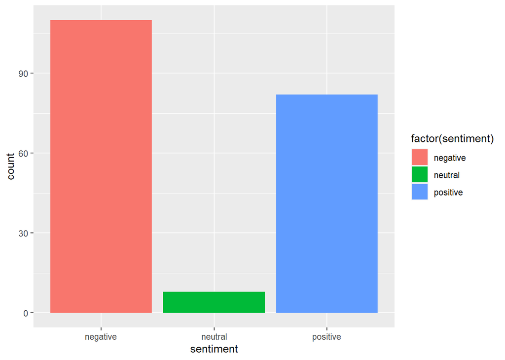

```r
data_text_editoriales$sentiment <- "neutral"
data_text_editoriales$sentiment[data_text_editoriales$score<0] <- "negative"
data_text_editoriales$sentiment[data_text_editoriales$score>0] <- "positive"
ggplot(data_text_editoriales,aes(x=sentiment,fill=factor(sentiment))) + geom_bar()
```

#### Nube de palabras positivas y negativas.

Para ver esto mismo de manera más visual hacemos dos nubes de palabras, la primera con las palabras que se repiten más a menudo de manera negativa y la segunda con las palabras que más se repiten de manera positiva.

**Nube negativa**

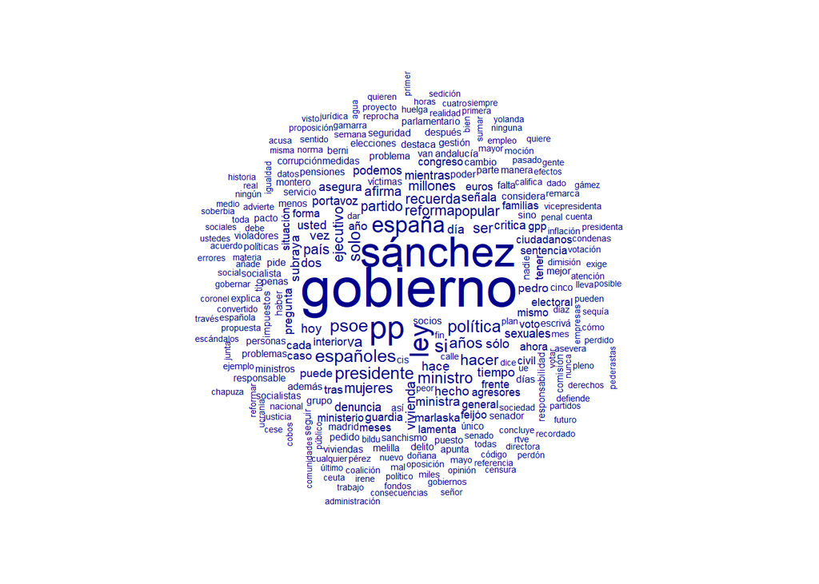

```r
data_tokens %>% tokens_subset(data_text_editoriales$sentiment == "negative") %>% dfm() %>%
  textplot_wordcloud(min_count=15)
```

**Nube positiva**

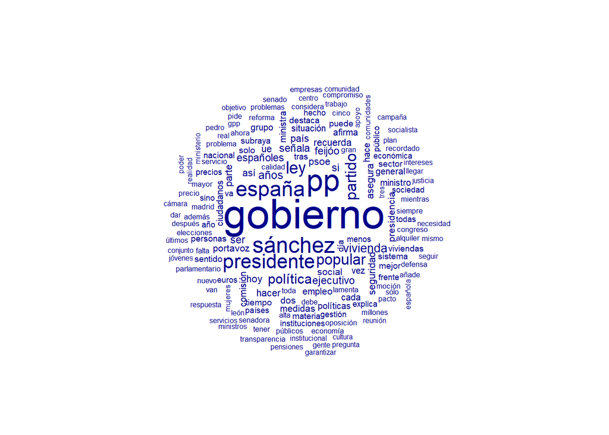

```r
data_tokens %>% tokens_subset(data_text_editoriales$sentiment == "positive") %>% dfm() %>%
  textplot_wordcloud(min_count=15)
```

Como vemos hay muchas palabras que se repiten, pero hay diferencias notables. La palabra central tanto en la nube de palabas negativa como en la nube de puntos positiva es **Gobierno**. Si observamos la palabra **Sánchez** vemos como en la nube de palabras negativa es de mayor tamaño que en la nube correspondiente a las palabras positivas. Además la palabra **España** aparece de forma contraria, en la nube de palabras positivas es de mayor tamaño que en la nube de palabras negativa.

### 3-2. Detección de temas.

#### Método LDA para detectar los K=5 temas.

Utilizamos este método de aprendizaje no supervisado por el que buscamos detectar patrones comunes entre los diferentes textos que analizamos.

```r
eds_corpus <- corpus(data_text_editoriales$text)

edsdfm <- tokens(eds_corpus,remove_punct = T,remove_numbers = T,
                 remove_url =T, remove_symbols = T) %>%
  tokens_remove(stopwords("spanish")) %>%
  dfm()
```

Después de usar LDA, hemos reducido toda la información de una tabla de palabras a dos tablas diferentes.

La primera tabla muestra los temas, cada uno está compuesto por varias palabras.

La segunda tabla muestra los documentos, cada uno está hecho de una combinación de temas.

```r
as.matrix(edsdfm)[1:3,1:6]
```

```
       features
docs    punto álgido campaña lugar domingo mayo
  text1     1      1       5     1       3    3
  text2     0      0       0     0       0    0
  text3     0      0       1     0       0    2
```

```r
dim(edsdfm)
```

```
[1]  200 9364
```

Construimos la tabla con los términos de cada texto.

```r
edsdfm2 <- tokens(eds_corpus,remove_punct = T,remove_numbers = T,
                 remove_url =T, remove_symbols = T) %>%
  tokens_remove(stopwords("es")) %>%
  tokens_ngrams(n=1:2) %>%
  dfm()

as.matrix(edsdfm2) %>% as.tibble() %>% select(tail(names(.),5))
```

```
# A tibble: 200 × 5
   reitera_moción moción_real real_sánchez sánchez_próximo `28m_elecciones`
            <dbl>       <dbl>        <dbl>           <dbl>            <dbl>
 1              0           0            0               0                0
 2              0           0            0               0                0
 3              0           0            0               0                0
 4              0           0            0               0                0
 5              0           0            0               0                0
 6              0           0            0               0                0
 7              0           0            0               0                0
 8              0           0            0               0                0
 9              0           0            0               0                0
10              0           0            0               0                0
# ℹ 190 more rows
```

```r
cdfm <- dfm_trim(edsdfm, min_docfreq = 10,max_termfreq = 100)
dim(cdfm)
```

```
[1] 200 721
```

Ahora estimamos siguiendo este modelo 5 temas.

```r
K <- 5
lda <- LDA(cdfm, k = K, method = "Gibbs",
           control = list(verbose=25L, seed = 123, burnin = 100, iter = 500))
```

[output not shown]

utilizamos la función **`get_terms`** para enumerar los 10 primeros términos.

```r
terms <- get_terms(lda, 10)
head(terms)
```

```
     Topic 1     Topic 2    Topic 3      Topic 4   Topic 5
[1,] "cada"      "mujeres"  "ministra"   "señala"  "afirma"
[2,] "seguridad" "reforma"  "tras"       "puede"   "feijóo"
[3,] "medidas"   "hoy"      "así"        "euros"   "congreso"
[4,] "personas"  "hecho"    "grupo"      "año"     "general"
[5,] "empleo"    "podemos"  "ministerio" "hace"    "marlaska"
[6,] "social"    "sexuales" "portavoz"   "critica" "mejor"
```

y hacemos lo mismo con **`get_topics`** para obtener el tema más importante de cada documento.

```r
topics <- get_topics(lda, 1)
head(topics)
```

```
text1 text2 text3 text4 text5 text6
    4     4     4     4     2     4
```

```r
# Topic 1
paste(terms[,1], collapse=", ")
```

```
[1] "cada, seguridad, medidas, personas, empleo, social, situación, materia, políticas, día"
```

```r
head(data_text_editoriales$text[topics==1], 1)
```

```
[1] " El Portavoz de Campaña del PP y Vicesecretario de Cultura y Sociedad Abierta, Borja Sémper , ha mantenido una reunión sectorial con destacados representantes de la provincia en el mundo de la cultura (nacional e internacional): el director de cine Manuel Martín Cuenca, el pintor y gestor cultu…
```

**Comprobamos nuestros datos echando un vistazo a los documentos.**

Hacemos lo mismo pero esta vez comprobando el top 5.

```r
# Topic 5
paste(terms[,5], collapse=", ")
```

```
[1] "afirma, feijóo, congreso, general, marlaska, mejor, mismo, sino, civil, guardia"
```

```r
head(data_text_editoriales$text[topics==5], 1)
```

```
[1] " • El portavoz de Hacienda del GPP, Gabriel Elorriaga, celebra el acuerdo final sobre la Ley del Mecenazgo, pero aclara que se reitera la plena vigencia de la aprobada por el PP en el 2002 con la introducción de pequeñas modificaciones adecuadas• De igual modo, considera que dichas modificacion…
```

#### Matriz Gamma.

Utilizamos la matriz gamma para visualizar el peso de cada uno de los temas en los documentos.

```r
head(lda@gamma)
```

```
           [,1]      [,2]      [,3]      [,4]      [,5]
[1,] 0.14685315 0.2307692 0.1888112 0.2727273 0.1608392
[2,] 0.18253968 0.1587302 0.1984127 0.3253968 0.1349206
[3,] 0.17482517 0.1678322 0.1048951 0.2937063 0.2587413
[4,] 0.14285714 0.2068966 0.1133005 0.3596059 0.1773399
[5,] 0.09923664 0.3587786 0.1526718 0.2213740 0.1679389
[6,] 0.12849162 0.2513966 0.1061453 0.3016760 0.2122905
```

#### Matriz beta.

Utilizamos la matriz beta para visualizar las palabras más frecuentes en cada uno de los temas.

```r
head(lda@beta)[,1:5]
```

```
           [,1]       [,2]       [,3]       [,4]      [,5]
[1,]  -7.103720 -10.537707 -10.537707 -10.537707 -10.53771
[2,] -10.548783  -6.835211  -5.063986  -4.841673 -10.54878
[3,]  -7.112433 -10.546420 -10.546420 -10.546420  -4.31005
[4,] -10.556880  -5.072083 -10.556880 -10.556880 -10.55688
[5,]  -6.145642  -8.142196 -10.540091  -8.142196 -10.54009
```

Seleccionamos los términos mas importantes de cada tema.

```r
dm_topics <- tidytext::tidy(lda,matrix="beta")
```

Nos quedamos con las 10 palabras más importantes de cada tema.

```r
dm_top_terms <- dm_topics %>%
  dplyr::group_by(topic) %>%
  dplyr::top_n(10, beta) %>%
  dplyr::ungroup() %>%
  dplyr::arrange(topic, -beta)
```

**Vamos a visualizar nuestros temas.**

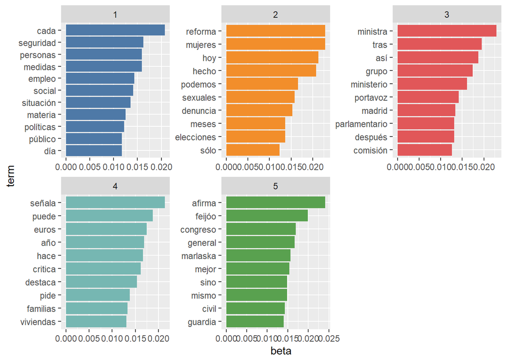

```r
dm_top_terms %>%
  dplyr::mutate(term = reorder(term, beta)) %>%
  ggplot(aes(term, beta, fill = factor(topic))) + geom_col(show.legend = FALSE) +
  facet_wrap(~ topic, scales = "free")+coord_flip()+scale_fill_tableau()
```

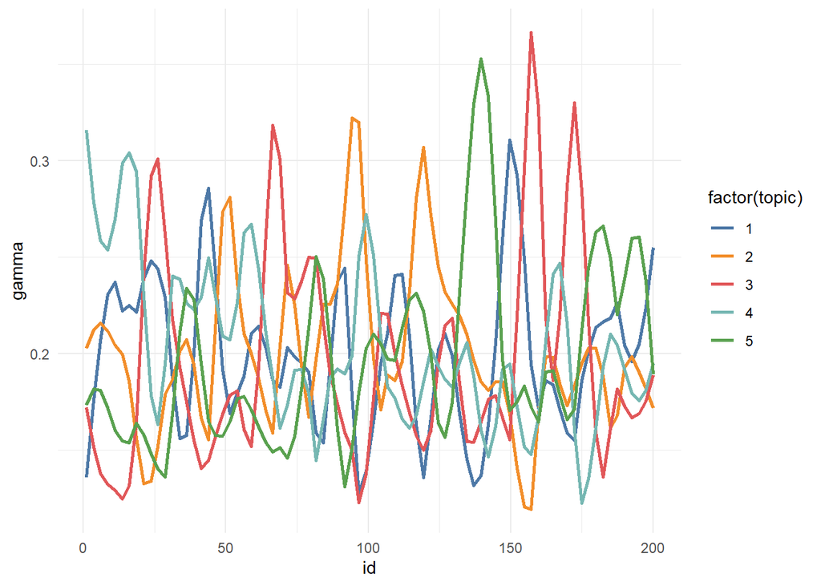

```r
data_text_editoriales$id <- c(1:200)

tidytext::tidy(lda,matrix="gamma") %>% merge(data_text_editoriales
        %>% mutate(document=paste0("text",1:nrow
                                   (data_text_editoriales))) %>%
  select(document,id),by="document") %>%
  ggplot(aes(x=id,y=gamma,col=factor(topic)))+geom_smooth(se = F,span=.1)+scale_color_tableau() + theme_minimal()
```